# Mid-Point Deliverable

Group AA6

5/21/2020

### Midpoint Deliverable- Abortion Statistics by Region

As a group, we believe that women should have reproductive rights. We think this would serve as an opportunity to delve into learning which reproductive resources are provided in the United States and the differences between in each state. We also find it interesting how there are many different sub-categories that fall under reproductive health. These topics include abortion rate, % change in abortion rate, change in number of clinics, % change in number of clinics, number of abortion clinics, % of women using contraceptives. Our project is to look specifically at the data of each region and state surrounding these topics. You can find the source of this dataset on the Guttmacher Institue and [Kaggle](https://www.kaggle.com/omer2040/usa-states-to-region). We joined these datasets to create our new dataset.

## Summary Info Paragraph

The dataset we used for this assignment was from the Guttmacher Institute, focusing on women’s reproductive health in each of the states in the USA. The data mainly highlights the number of abortion clinics and family planning clinics available per state as well as the information on the contraceptive usage for women aged 18-49.

For our summary table we did several calculations to find (during the year of 2017):

The region with the least number of clinics was the Midwest with a total of 91 clinics in that region. The region with the most number of clinics was the West with a total of 277 clinics in that region. The region with the lowest percent of women using contraceptive was 68.6642857 percent. The region with the highest percent of women using contraceptive was 71.86 percent.

## Summary Table

This table was created to very easily display the numbers of the abortion rates, Contraception Percent, and Number of Abortion Clinics in each region. We used the group_by, sum, and mean functions to compute our results for each region. We found these columns to be the most helpful for our project goal and answering our questions. Our summary table displayed that the west region had the highest contraception rate and number of abortion clinics. The midwest had the lowest abortion rate and number of abortion clinics.

| Region | Abortion Rate | Contraception Percent | Number of Abortion Clinics |
| --- | --- | --- | --- |
| Midwest | 8.425000 | 70.15556 | 91 |
| Northeast | 16.077778 | 71.80000 | 245 |
| South | 11.241176 | 68.66429 | 195 |
| West | 9.776923 | 71.86000 | 277 |

## Chart 1: Bar Graph

A bar graph is chosen to display the number of abortion clinics in the four regions of the United States. This is the graph of choice because it’s able to show the varying differences in the number of abortion clinics. It’s also ideal because the numerical data points aren’t closely related. As shown below, the West region has the most abortion clinics - more than 250, with the midwest region having the least - less than 100.

Often times, abortion clinics are closely correlated to political views. With the west region consisting of mostly left-winged, liberalist who are pro-choice, it makes sense that there are more abortion clinics in the west compared to the midwest where more right-winged conservatives pro-life individuals reside.

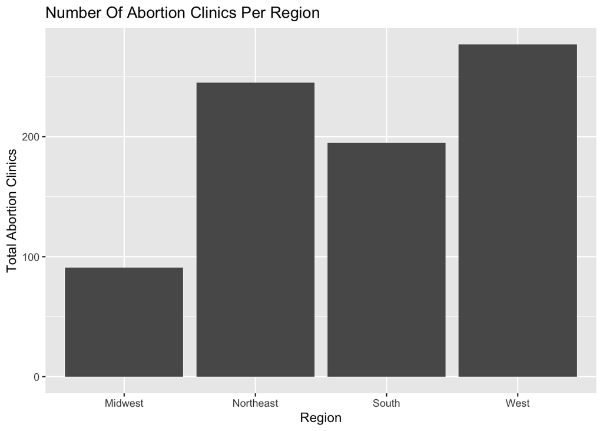

## Chart 2: Scatterplot

A scatterplot was used to display the amount of total abortion clinics versus the total abortion rates based on the region. This is the graph of choice because it allows the viewer to see if there is a correlation between abortion clinics and rate in different regions.

This graph showcases that there is no correlation between the amount of abortion clinics and the amount of abortion rates per region. This means that these two factors are not codependent and do not influence each other. Even if there are more more abortion clinics this will not mean more people need an abortion.

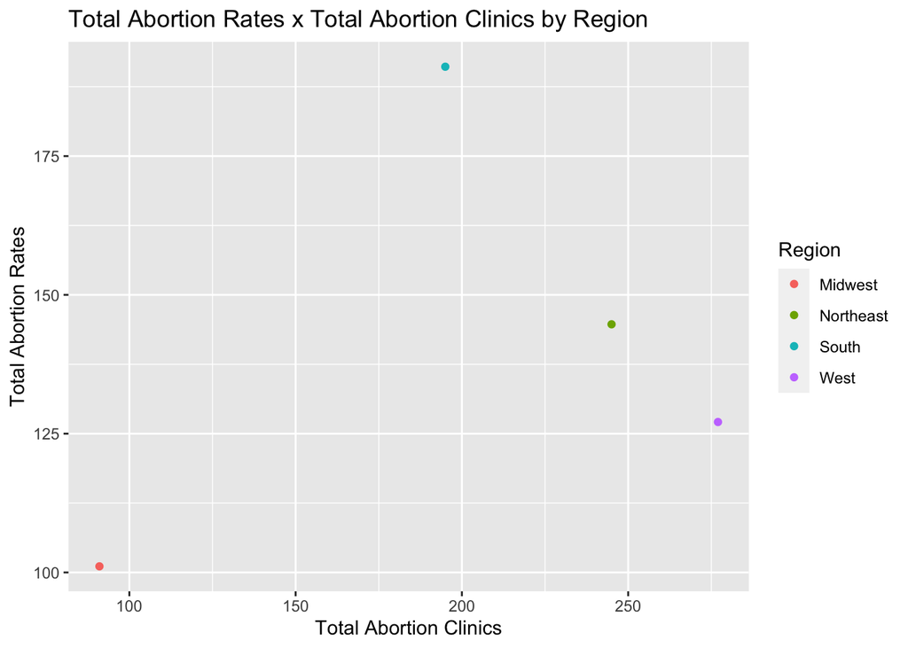

## Char 3: Scatterplot

This scatterplot was used to display the percentage of women aged 18 to 49 who used contraceptives in 2017 versus the number of Abortion Clinics in a region. We chose to do a scatterplot because it allows the viewer to easily see if there is a correlation between the number of abortion cinlics and the percentage of women using contraceptives. It also allows the viewer to easily see which region that data is from.

This graph shoes that there probably is not any correlation between the number of abortion clinics and the percentage of women taking contraceptives. This means that the amount of abortion clinics near woemn does not seem to have any effect on if the women will take contraceptives.

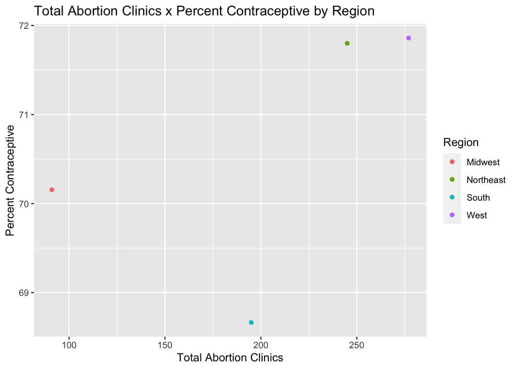